# Enrichment Analysis

Steve Pederson

20 February, 2019

## Setup

```r
library(BSgenome.Drerio.UCSC.danRer11)
library(AnnotationHub)
library(plyranges)
library(fgsea)
library(magrittr)
library(scales)
library(pander)
library(tidyverse)
```

### Convert Ensembl to UCSC

- In this analysis, the genome used was custom built as BSgenome object using the function `BSgenome::forgeBSgenomeDataPkg()`, using the 2bit file provided as `AH65657` in the package `AnnotationHub()`.

```r
z11 <- BSgenome.Drerio.UCSC.danRer11
ah <- AnnotationHub() %>% subset(species == "Danio rerio")
gr <- ah[["AH64578"]]
```

- The GRanges object containing all annotations for known features was then loaded. However, the compatibility of the underlying `seqinfo` objects needs to be addressed. The seqinfo object of the main genome contains more features, and as such will be used as the foundation for the `GRanges` object. Whilst the GRanges object is based on Ensembl annotations and chromosome identifiers, the genome sequences are based on UCSC chromosome identifiers.

```r
ucscLevels <- seqlevels(z11)
```

- Scaffolds will need to have:
  - the `v` converted to a ‘.’
  - `chr**_` will need to removed from the prefix
  - `_alt` will need to be removed form the suffix

```r
ensLevels <- ucscLevels %>%
    str_remove_all("^chr") %>%
    str_remove_all("^[0-9Un]+_") %>%
    str_remove_all("_alt") %>%
    str_replace_all("v", ".") %>%
    str_replace_all("^M$", "MT")
```

```r
ens2Ucsc <- structure(ucscLevels, names = ensLevels)
seqlevels(gr) <- ens2Ucsc[seqlevels(gr)]
seqinfo(gr, new2old = match(seqlevels(z11), seqlevels(gr))) <- seqinfo(z11)
```

### Extract 3’ UTR

```r
utr3 <- subset(gr, type == "three_prime_utr")
```

```r
utr3Seq <- Views(z11, utr3) %>% DNAStringSet()
names(utr3Seq) <- paste(utr3$transcript_id, utr3$gene_name, granges(utr3), sep = "_")
writeXStringSet(utr3Seq, "utr3.fa.gz", compress = TRUE)
```

A total of 34,772 sequences were exported

### Extract 5’ UTR

```r
utr5 <- subset(gr, type == "five_prime_utr")
```

```r
utr5Seq <- Views(z11, utr5) %>% DNAStringSet()
names(utr5Seq) <- paste(utr5$transcript_id, utr5$gene_name, granges(utr5), sep = "_")
writeXStringSet(utr5Seq, "utr5.fa.gz", compress = TRUE)
```

A total of 48,952 sequences were exported.

## Import SIREs results

### 3’ UTR

Results from scans of the above sequences using the [SIREs website](http://ccbg.imppc.org/sires/) were loaded as data frames, with co-ordinates converted to the underlying genomic co-ordinates, as opposed to being in reference to the submitted sequences

```r
ireUtr3 <- file.path("utr3_sires.gff.gz") %>%
    import.gff() %>%
    as.data.frame(stringsAsFactors = FALSE) %>%
    as_tibble()
```

```r
lsm2 <- gr %>%
    subset(transcript_id == "ENSDART00000190509") %>%
    subset(type == "three_prime_utr") %>%
    with(paste("ENSDART00000190509", "LSM2", granges(.), sep = "_"))
```

As the `gene_name` field for *LSM2* contained spaces and the phrase *“(1 of many)”*, this needed to be manually corrected. The loaded matches to IREs in the UTR3 were then converted to a GRanges object.

```r
ireUtr3 %<>%
    mutate(seqnames = as.character(seqnames),
                 seqnames = str_replace(seqnames, "_chrUn_", "_chrUn-"),
                 seqnames = case_when(
                    grepl("ENSDART00000190509", seqnames) ~ lsm2,
                    !grepl("ENSDART00000190509", seqnames) ~ seqnames
                 )) %>%
    dplyr::select(-strand) %>%
    separate(seqnames, c("transcript_id", "gene_name", "location"), sep = "_") %>%
    mutate(location = str_replace(location, "chrUn-", "chrUn_")) %>%
    separate(
        location,
        into = c("seqnames", "trans_start", "trans_end", "strand"),
        sep = "[:-]"
    ) %>%
    mutate_at(c("trans_start", "trans_end"), funs(as.integer)) %>%
    mutate(strand = case_when(
        strand == "" ~ "-",
        strand == "+" ~ "+"
    ),
    start = ifelse(
        strand == "+",
        trans_start + start - 1L,
        trans_end - end + 1L
    ),
    end = start + width - 1) %>%
    dplyr::select(-contains("trans_")) %>%
    makeGRangesFromDataFrame(
        keep.extra.columns = TRUE,
        seqinfo = seqinfo(gr),
        seqnames.field = "seqnames",
        start.field = "start",
        end.field = "end",
        strand.field = "strand")
ireUtr3$gene_id <- mcols(gr)$gene_id[match(ireUtr3$transcript_id, gr$transcript_id)]
```

A total of 1,737 IREs were found across 1,207 genes when inspecting the 3’UTR sequences. These can be summarised as:

- **c8_class**:

  | good | wrong |
  | --- | --- |
  | 783 | 954 |

- **pred_loop_class**:

  | good | wrong |
  | --- | --- |
  | 552 | 1185 |

- **pairs_class**:

  | good | ok |
  | --- | --- |
  | 417 | 1320 |

- **quality**:

  | High | Low | Medium |
  | --- | --- | --- |
  | 147 | 1054 | 536 |

### 5’ UTR

The same process was repeated for 5’ UTR IREs, with the exception that this time the gene *TMCC1* required manual correcting.

```r
ireUtr5 <- file.path("utr5_sires.gff.gz") %>%
    import.gff() %>%
    as.data.frame(stringsAsFactors = FALSE) %>%
    as_tibble()
```

```r
tmcc1 <- gr %>%
    subset(transcript_id == "ENSDART00000193119") %>%
    subset(type == "five_prime_utr") %>%
    with(paste("ENSDART00000193119", "TMCC1", granges(.), sep = "_"))
```

The loaded matches to IREs in the UTR5 were then converted to a GRanges object.

```r
ireUtr5 %<>%
    mutate(seqnames = as.character(seqnames),
                 seqnames = str_replace(seqnames, "_chrUn_", "_chrUn-"),
                 seqnames = case_when(
                    grepl("ENSDART00000193119", seqnames) ~ tmcc1,
                    !grepl("ENSDART00000193119", seqnames) ~ seqnames
                 )) %>%
    dplyr::select(-strand) %>%
    separate(seqnames, c("transcript_id", "gene_name", "location"), sep = "_") %>%
    mutate(location = str_replace(location, "chrUn-", "chrUn_")) %>%
    separate(
        location,
        into = c("seqnames", "trans_start", "trans_end", "strand"),
        sep = "[:-]"
    ) %>%
    mutate_at(c("trans_start", "trans_end"), funs(as.integer)) %>%
    mutate(strand = case_when(
        strand == "" ~ "-",
        strand == "+" ~ "+"
    ),
    start = ifelse(
        strand == "+",
        trans_start + start - 1L,
        trans_end - end + 1L
    ),
    end = start + width - 1) %>%
    dplyr::select(-contains("trans_")) %>%
    makeGRangesFromDataFrame(
        keep.extra.columns = TRUE,
        seqinfo = seqinfo(gr),
        seqnames.field = "seqnames",
        start.field = "start",
        end.field = "end",
        strand.field = "strand")
ireUtr5$gene_id <- mcols(gr)$gene_id[match(ireUtr5$transcript_id, gr$transcript_id)]
```

A total of 558 IREs were found across 393 genes when inspecting the 5’UTR sequences. These can be summarised as:

- **c8_class**:

  | good | wrong |
  | --- | --- |
  | 243 | 315 |

- **pred_loop_class**:

  | good | wrong |
  | --- | --- |
  | 201 | 357 |

- **pairs_class**:

  | good | ok |
  | --- | --- |
  | 144 | 414 |

- **quality**:

  | High | Low | Medium |
  | --- | --- | --- |
  | 67 | 299 | 192 |

## Enrichment Analysis

### Gene Set Definitions

At this point, we need to create multiple (overlapping) gene sets which define the putative IREs. The initial gene-sets being formed are:

- **3’UTR HQ**: The High quality IREs in the 3’ UTR
- **3’UTR ALL**: All putative IREs in the 3’UTR
- **5’UTR HQ**: The High quality IREs in the 5’ UTR
- **5’UTR ALL**: All putative IREs in the 5’UTR

```r
ireSets <- list(
    utr3HQ = ireUtr3 %>%
        subset(quality == "High") %>%
        mcols() %>%
        extract2("gene_name") %>%
        unique(),
    utr3ALL = ireUtr3 %>%
        mcols() %>%
        extract2("gene_name") %>%
        unique(),
    utr5HQ = ireUtr5 %>%
        subset(quality == "High") %>%
        mcols() %>%
        extract2("gene_name") %>%
        unique(),
    utr5ALL = ireUtr5 %>%
        mcols() %>%
        extract2("gene_name") %>%
        unique()
)
```

This gave gene sets of the following sizes:

| utr3HQ | utr3ALL | utr5HQ | utr5ALL |
| --- | --- | --- | --- |
| 106 | 1205 | 49 | 390 |

### GSEA

The tables containing fold-change (logFC), $t$-statistics and $p$-values from the previous analysis were loaded into the workspace.

```r
expressionData <- list.files(pattern = "tsv.gz", full.names = TRUE) %>%
    sapply(gzfile, simplify = FALSE) %>%
    lapply(read_tsv) %>%
    set_names(basename(names(.))) %>%
    set_names(str_remove(names(.), ".tsv.gz"))
```

#### Ranks using $t$-statistics

```r
nPerm <- 1e5
m <- length(expressionData)*length(ireSets)
gseaByT <- expressionData %>%
    lapply(function(x){
        ranks <- structure(x$t, names = x$symbol) %>% sort
        fgsea(ireSets, ranks, nperm = nPerm, nproc = 6)
    }) %>%
    lapply(function(x){
        x$FDR <- x$padj
        x$padj <- p.adjust(x$pval, "bonferroni", n = m)
        x
    })
```

A simple GSEA (Gene Set Enrichment Analysis) was performed on all three gene lists (*FADvFS*, *FADvWT* and *FSvWT*) ranked by $t$-statistic, using the 4 sets of IREs as defined above. In order to determine significance, 100,000 permutations were performed. Given the three comparisons and four gene-sets, all $p$-values were additionally corrected using Bonferroni’s method across the entire set of comparisons, as well as leaving the default FDR adjusted p-values returned by the algorithm. A potentially significant result was found in the comparison between FAD-like mutants and WT when including all potential IREs, including the low quality predictions.

Results for DE genes in the comparison between FS & FAD mutants

| pathway | pval | FDR | padj | ES | NES | nMoreExtreme | size |
| --- | --- | --- | --- | --- | --- | --- | --- |
| utr3HQ | 0.2469 | 0.6797 | 1 | -0.2514 | -1.11 | 12740 | 102 |
| utr3ALL | 0.4851 | 0.6797 | 1 | 0.1732 | 0.994 | 22128 | 1108 |
| utr5HQ | 0.5098 | 0.6797 | 1 | -0.2556 | -0.9663 | 25932 | 46 |
| utr5ALL | 0.7157 | 0.7157 | 1 | 0.1773 | 0.9264 | 34069 | 343 |

Results for DE genes in the comparison between FS mutants & WT

| pathway | pval | FDR | padj | ES | NES | nMoreExtreme | size |
| --- | --- | --- | --- | --- | --- | --- | --- |
| utr3HQ | 0.8142 | 0.8142 | 1 | -0.1891 | -0.8345 | 44376 | 102 |
| utr3ALL | 0.0279 | 0.1116 | 0.3348 | -0.2058 | -1.172 | 1837 | 1108 |
| utr5HQ | 0.5846 | 0.7795 | 1 | 0.2399 | 0.927 | 27568 | 46 |
| utr5ALL | 0.06421 | 0.1284 | 0.7706 | -0.232 | -1.203 | 3751 | 343 |

Results for DE genes in the comparison between FAD mutants & WT

| pathway | pval | FDR | padj | ES | NES | nMoreExtreme | size |
| --- | --- | --- | --- | --- | --- | --- | --- |
| utr3HQ | 0.2717 | 0.5435 | 1 | -0.2516 | -1.098 | 14637 | 102 |
| utr3ALL | 0.007662 | 0.03065 | 0.09194 | -0.2168 | -1.218 | 491 | 1108 |
| utr5HQ | 0.7848 | 0.7848 | 1 | 0.2148 | 0.8192 | 37419 | 46 |
| utr5ALL | 0.5003 | 0.667 | 1 | -0.1921 | -0.9846 | 28897 | 343 |

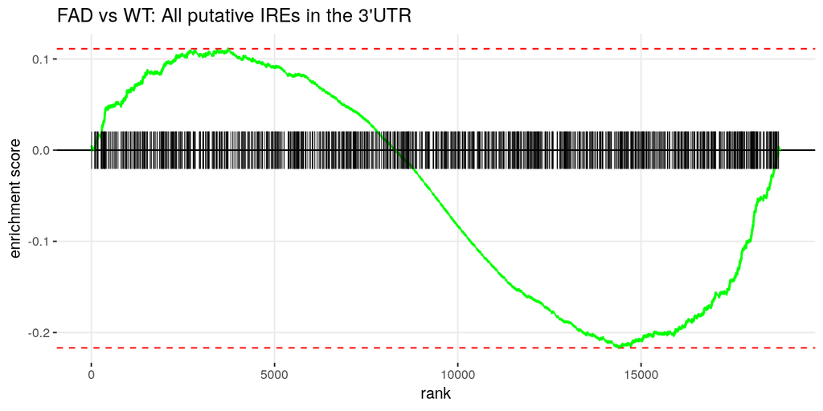

*Enrichment for ALL UTR3 IREs in the comparison between FAD_like mutants and WT. Whilst enrichment was technically found in the down-regulated genes, it was noted that there seemed to be an apparent symmetry to the enrichment score. However, testing using p-values for the ranking score failed to reveal any significance.*

## SessionInfo

**R version 3.5.2 (2018-12-20)**

**Platform:** x86_64-pc-linux-gnu (64-bit)

**locale:** *LC_CTYPE=en_AU.UTF-8*, *LC_NUMERIC=C*, *LC_TIME=en_AU.UTF-8*, *LC_COLLATE=en_AU.UTF-8*, *LC_MONETARY=en_AU.UTF-8*, *LC_MESSAGES=en_AU.UTF-8*, *LC_PAPER=en_AU.UTF-8*, *LC_NAME=C*, *LC_ADDRESS=C*, *LC_TELEPHONE=C*, *LC_MEASUREMENT=en_AU.UTF-8* and *LC_IDENTIFICATION=C*

**attached base packages:** *stats4*, *parallel*, *stats*, *graphics*, *grDevices*, *utils*, *datasets*, *methods* and *base*

**other attached packages:** *forcats(v.0.4.0)*, *stringr(v.1.4.0)*, *dplyr(v.0.8.0.1)*, *purrr(v.0.3.0)*, *readr(v.1.3.1)*, *tidyr(v.0.8.2)*, *tibble(v.2.0.1)*, *ggplot2(v.3.1.0)*, *tidyverse(v.1.2.1)*, *pander(v.0.6.3)*, *scales(v.1.0.0)*, *magrittr(v.1.5)*, *fgsea(v.1.8.0)*, *Rcpp(v.1.0.0)*, *plyranges(v.1.2.0)*, *AnnotationHub(v.2.14.3)*, *BSgenome.Drerio.UCSC.danRer11(v.0.99.0)*, *BSgenome(v.1.50.0)*, *rtracklayer(v.1.42.1)*, *Biostrings(v.2.50.2)*, *XVector(v.0.22.0)*, *GenomicRanges(v.1.34.0)*, *GenomeInfoDb(v.1.18.2)*, *IRanges(v.2.16.0)*, *S4Vectors(v.0.20.1)* and *BiocGenerics(v.0.28.0)*

**loaded via a namespace (and not attached):** *nlme(v.3.1-137)*, *bitops(v.1.0-6)*, *matrixStats(v.0.54.0)*, *lubridate(v.1.7.4)*, *bit64(v.0.9-7)*, *httr(v.1.4.0)*, *tools(v.3.5.2)*, *backports(v.1.1.3)*, *R6(v.2.4.0)*, *DBI(v.1.0.0)*, *lazyeval(v.0.2.1)*, *colorspace(v.1.4-0)*, *withr(v.2.1.2)*, *tidyselect(v.0.2.5)*, *gridExtra(v.2.3)*, *curl(v.3.3)*, *bit(v.1.1-14)*, *compiler(v.3.5.2)*, *cli(v.1.0.1)*, *rvest(v.0.3.2)*, *Biobase(v.2.42.0)*, *xml2(v.1.2.0)*, *DelayedArray(v.0.8.0)*, *labeling(v.0.3)*, *digest(v.0.6.18)*, *Rsamtools(v.1.34.1)*, *rmarkdown(v.1.11)*, *pkgconfig(v.2.0.2)*, *htmltools(v.0.3.6)*, *highr(v.0.7)*, *rlang(v.0.3.1)*, *readxl(v.1.3.0)*, *rstudioapi(v.0.9.0)*, *RSQLite(v.2.1.1)*, *shiny(v.1.2.0)*, *generics(v.0.0.2)*, *jsonlite(v.1.6)*, *BiocParallel(v.1.16.6)*, *RCurl(v.1.95-4.11)*, *GenomeInfoDbData(v.1.2.0)*, *Matrix(v.1.2-15)*, *munsell(v.0.5.0)*, *stringi(v.1.3.1)*, *yaml(v.2.2.0)*, *SummarizedExperiment(v.1.12.0)*, *zlibbioc(v.1.28.0)*, *plyr(v.1.8.4)*, *grid(v.3.5.2)*, *blob(v.1.1.1)*, *promises(v.1.0.1)*, *crayon(v.1.3.4)*, *lattice(v.0.20-38)*, *haven(v.2.1.0)*, *hms(v.0.4.2)*, *knitr(v.1.21)*, *pillar(v.1.3.1)*, *fastmatch(v.1.1-0)*, *XML(v.3.98-1.17)*, *glue(v.1.3.0)*, *evaluate(v.0.13)*, *data.table(v.1.12.0)*, *BiocManager(v.1.30.4)*, *modelr(v.0.1.4)*, *httpuv(v.1.4.5.1)*, *cellranger(v.1.1.0)*, *gtable(v.0.2.0)*, *assertthat(v.0.2.0)*, *xfun(v.0.4)*, *mime(v.0.6)*, *xtable(v.1.8-3)*, *broom(v.0.5.1)*, *later(v.0.8.0)*, *GenomicAlignments(v.1.18.1)*, *AnnotationDbi(v.1.44.0)*, *memoise(v.1.1.0)* and *interactiveDisplayBase(v.1.20.0)*